# Hópverkefni 3 STÆ203

Ásgerður, Vilborg

2024-02-24

```r
library(tidyverse)
```

```r
library(ggplot2)
set.seed(1)
```

#### Liður 1: Líkindadreifingar slembinna fyrirbæra

- Komið með dæmi um þrjú slembin fyrirbæri, X, Y og Z, eitt sem má lýsa með Poisson dreifingu, eitt sem má lýsa með tvíkostadreifingu og það þriðja sem má lýsa með normaldreifingu.
- Lítið á útkomu slembnu fyrirbæranna sem slembistærðirnar X, Y og Z og veljið heppileg gildi á stikum líkindadreifinganna sem lýsa þeim.
- Teiknið mynd af þéttifalli/massafalli hverrrar og einnar slembistærðar með því að herma 100 000 útkomur þeirra (með `rnorm`, `rbinom`eða `rpois`) og teikna graf með útkomunum.

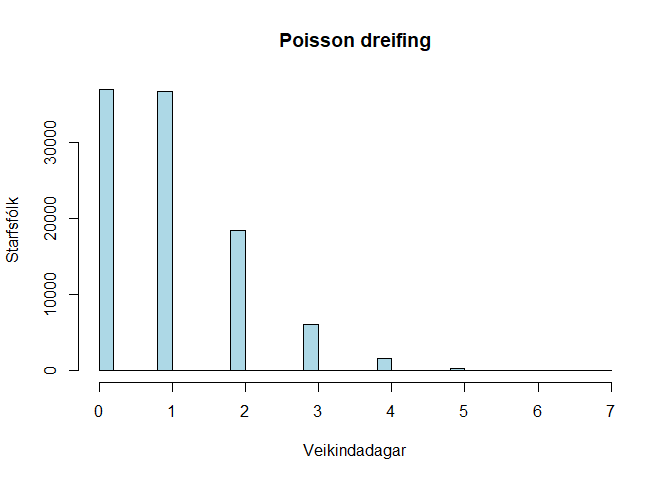

```r
X <- rpois(100000, 1) # fjöldi veikindadaga á mánuði hjá stafsfólki
Y <- rnorm(100000, 1,10) # Meðalhiti á köldum stað
Z <- rbinom(100000,3,0.1) # Að hitta 3 körfur í röð, ef hvart kast er 10% líkur á að hitta

hist(X, breaks = 30, col = "lightblue", main = "Poisson dreifing", xlab = "Veikindadagar", ylab = "Starfsfólk")
```

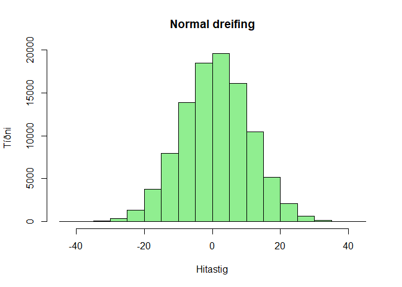

```r
hist(Y, breaks = 30, col = "lightgreen", main = "Normal dreifing", xlab = "Hitastig", ylab = "Tíðni")
```

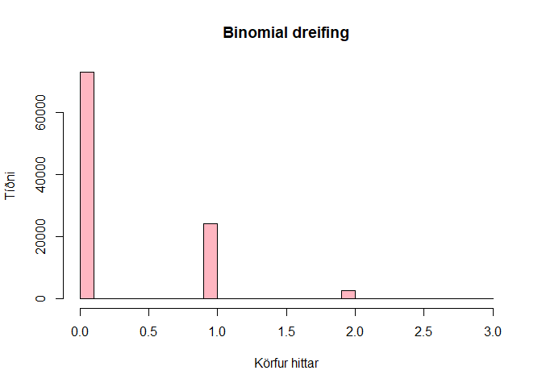

```r
hist(Z, breaks = 30, col = "lightpink", main = "Binomial dreifing", xlab = "Körfur hittar", ylab = "Tíðni")
```

#### Liður 2: Búum til mörg lítil úrtök (n=10)

- Núna ætlið þið skoða hvað myndi gerast ef þið mynduð framkvæma tilraun þar sem þið veljið úrtak af stærð **10** fyrir hverja af slembistærðunum X, Y og Z, þ.e.a.s. þrjú ólík úrtök, hvert með 10 útkomum.
- Fyrir hvert úrtak ætlið þið að reikna lýsistærðirnar meðaltal og miðgildi.
- Þetta ætlið þið að endurtaka mjög oft (100 000 sinnum) og sjá hve mikið lýsistærðirnar geta breyst í hvert skipti sem nýtt úrtak er valið.
- Ein leið til þess er að búa til gagnatöflu með sex dálkum en 100 000 línum. Einn dálkur fyrir hverja samsetningu af slembistærð og lýsistærð og eina línu fyrir hvert úrtak. Hér er kóðabútur til að koma ykkur af stað:

```r
dat10 <- data.frame(
  medal_x = replicate(100000, mean(rnorm(10, 0, 1))),      # Meðaltal úrtaks fyrir X
  midgildi_x = replicate(100000, median(rnorm(10, 0, 1))), # Miðgildi úrtaks fyrir X

  medal_y = replicate(100000, mean(rpois(10, 1))),         # Meðaltal úrtaks fyrir Y
  midgildi_y = replicate(100000, median(rpois(10, 1))),    # Miðgildi úrtaks fyrir Y

  medal_z = replicate(100000, mean(rbinom(10, 3, 0.1))),   # Meðaltal úrtaks fyrir Z
  midgildi_z = replicate(100000, median(rbinom(10, 3, 0.1))) # Miðgildi úrtaks fyrir Z
)
```

```r
medaltal <- colMeans(dat10)
print(medaltal)
```

```
##      medal_x   midgildi_x      medal_y   midgildi_y      medal_z   midgildi_z
## 0.0005059198 0.0005700725 0.9994550000 0.8596300000 0.2995820000 0.0668200000
```

```r
urtak10 <- sample_n(dat10, 10)
knitr::kable(urtak10)
```

| medal_x | midgildi_x | medal_y | midgildi_y | medal_z | midgildi_z |
| --- | --- | --- | --- | --- | --- |
| 0.1513485 | 0.0935059 | 0.7 | 1.0 | 0.2 | 0.0 |
| 0.0634706 | -0.4381988 | 0.5 | 0.5 | 0.3 | 0.0 |
| 0.1454461 | -0.1019604 | 0.9 | 1.0 | 0.1 | 0.0 |
| 0.0350079 | 0.2660694 | 0.8 | 1.0 | 0.2 | 0.0 |
| -0.2465016 | -0.1631726 | 1.0 | 2.0 | 0.4 | 0.0 |
| 0.1715315 | -0.2514661 | 1.3 | 0.0 | 0.1 | 0.0 |
| -0.1738695 | 0.1622875 | 1.1 | 1.0 | 0.4 | 0.0 |
| -0.0803788 | -0.0484742 | 0.7 | 1.0 | 0.3 | 0.0 |
| -0.2896416 | 0.0042733 | 0.8 | 1.0 | 0.5 | 0.0 |
| -0.7681062 | -0.2613076 | 1.2 | 1.0 | 0.2 | 0.5 |

#### Liður 3: Berum saman slembistærðir og lýsistærðir

- Núna ætlið þið að áætla úrtaksdreifingu lýsistærðanna sem þið voruð að reikna með því að teikna stuðlarit hvers og eins dálks (alls sex gröf).
- Fyrir hvaða slembistærðir og lýsistærðir virðist úrtaksdreifing lýsistærðanna samfelld?
- Fyrir hvaða slembistærðir og lýsistærðir virðist úrtaksdreifing lýsistærðanna samhverf?
- Reiknið meðaltal hvers og eins dálks. Hversu líkt er það væntigildi slembistærðanna X, Y og Z í hverju tilviki?
- Reiknið dreifni hvers og eins dálks. Er mikill munur er á dreifni úrtaksdreifingu meðaltals og dreifni úrtaksdreifingu miðgildis sömu slembistærðar?

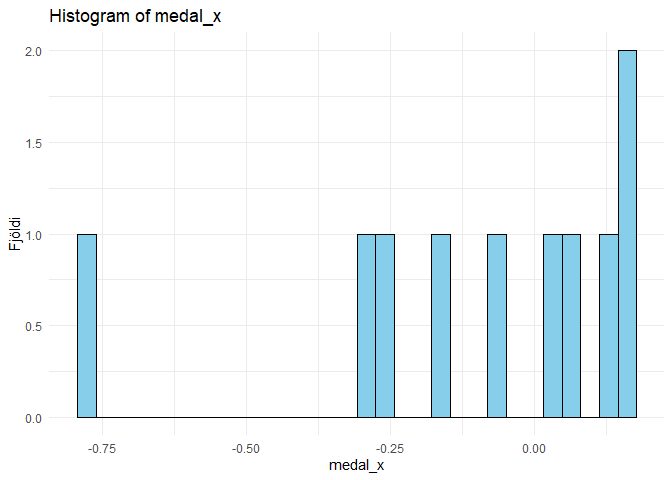

```r
ggplot(urtak10, aes(x = medal_x)) +
  geom_histogram(fill = "skyblue", color = "black", bins = 30) +
  labs(title = "Histogram of medal_x", x = "medal_x", y = "Fjöldi") +
  theme_minimal()
```

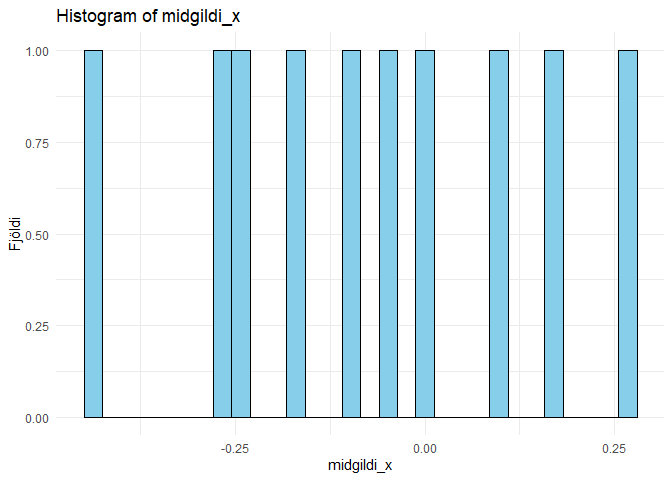

```r
ggplot(urtak10, aes(x = midgildi_x)) +
  geom_histogram(fill = "skyblue", color = "black", bins = 30) +
  labs(title = "Histogram of midgildi_x", x = "midgildi_x", y = "Fjöldi") +
  theme_minimal()
```

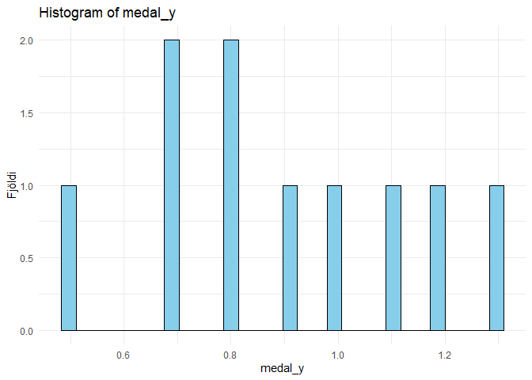

```r
ggplot(urtak10, aes(x = medal_y)) +
  geom_histogram(fill = "skyblue", color = "black", bins = 30) +
  labs(title = "Histogram of medal_y", x = "medal_y", y = "Fjöldi") +
  theme_minimal()
```

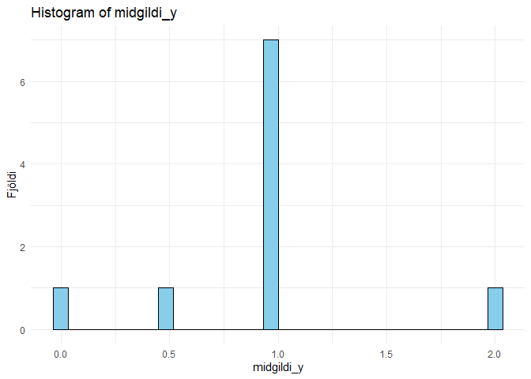

```r
ggplot(urtak10, aes(x = midgildi_y)) +
  geom_histogram(fill = "skyblue", color = "black", bins = 30) +
  labs(title = "Histogram of midgildi_y", x = "midgildi_y", y = "Fjöldi") +
  theme_minimal()
```

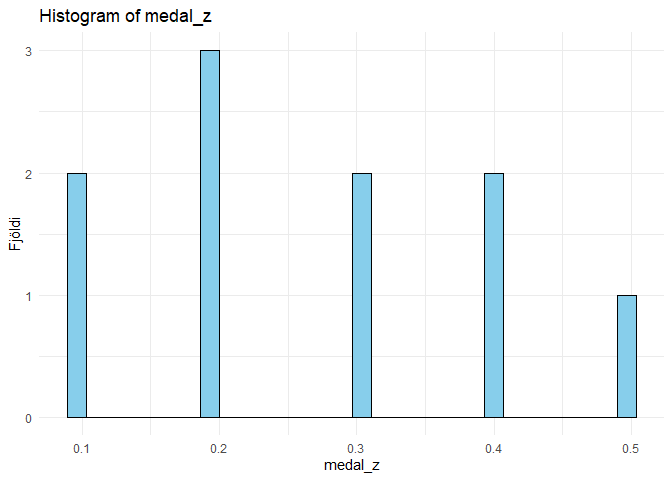

```r
ggplot(urtak10, aes(x = medal_z)) +
  geom_histogram(fill = "skyblue", color = "black", bins = 30) +
  labs(title = "Histogram of medal_z", x = "medal_z", y = "Fjöldi") +
  theme_minimal()
```

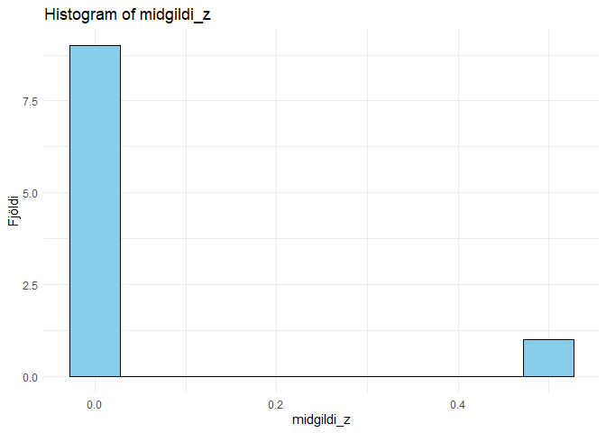

```r
ggplot(urtak10, aes(x = midgildi_z)) +
  geom_histogram(fill = "skyblue", color = "black", bins = 10) +
  labs(title = "Histogram of midgildi_z", x = "midgildi_z", y = "Fjöldi") +
  theme_minimal()
```

```r
mean10 <- colMeans(urtak10) #meðaltal
var10 <- apply(urtak10, 2, var) #dreifni

tafla10 <- data.frame(Mean = mean10, Variance = var10)

knitr::kable(tafla10)
```

|  | Mean | Variance |
| --- | --- | --- |
| medal_x | -0.0991693 | 0.0835251 |
| midgildi_x | -0.0738444 | 0.0460298 |
| medal_y | 0.9000000 | 0.0622222 |
| midgildi_y | 0.9500000 | 0.2472222 |
| medal_z | 0.2700000 | 0.0178889 |
| midgildi_z | 0.0500000 | 0.0250000 |

Samhverf: midgilidi_x

Mikill munur er á dreifni meðaltals og miðgildis fyrir allar slembistærðirnar.

#### Liður 4: Stækkum úrtakið (n=30)

- Endurtakið liði 2 og 3, nema nú fyrir úrtak af stærð 30.

```r
urtak30 <- sample_n(dat10, 30)
knitr::kable(urtak30)
```

| medal_x | midgildi_x | medal_y | midgildi_y | medal_z | midgildi_z |
| --- | --- | --- | --- | --- | --- |
| -0.0072957 | -0.0946055 | 1.1 | 1.5 | 0.4 | 0.0 |
| 0.1325826 | 0.3576936 | 0.6 | 0.5 | 0.5 | 0.0 |
| -0.2798706 | 0.2940165 | 1.1 | 0.5 | 0.5 | 0.0 |
| 0.2874148 | 0.2987579 | 1.5 | 0.0 | 0.4 | 0.0 |
| -0.4506916 | -0.5906658 | 1.2 | 0.5 | 0.0 | 0.0 |
| 0.3750113 | 0.0560761 | 0.8 | 1.0 | 0.6 | 0.0 |
| -0.1034092 | -0.2732323 | 0.3 | 0.5 | 0.3 | 1.0 |
| -0.0649103 | -0.1803715 | 0.7 | 1.0 | 0.2 | 0.0 |
| 0.4536215 | 0.0057401 | 1.3 | 1.0 | 0.0 | 0.0 |
| -0.2000987 | -0.1408581 | 0.9 | 1.0 | 0.7 | 0.5 |
| -0.0075711 | -0.2001627 | 1.3 | 1.0 | 0.6 | 0.5 |
| 0.4163222 | -0.4257398 | 0.9 | 1.5 | 0.4 | 0.0 |
| -0.0952805 | 0.3539789 | 1.2 | 1.0 | 0.3 | 0.0 |
| 0.5111128 | -0.3179783 | 0.9 | 0.0 | 0.2 | 0.0 |
| 0.0261672 | -0.3462140 | 0.8 | 1.0 | 0.4 | 0.0 |
| 0.4209226 | 0.4972384 | 1.2 | 1.0 | 0.5 | 0.0 |
| 0.0060209 | -0.8297680 | 0.9 | 0.0 | 0.4 | 0.0 |
| 0.2140988 | -0.3848372 | 0.3 | 1.0 | 0.4 | 0.0 |
| -0.1578261 | -0.0634900 | 1.1 | 1.0 | 0.5 | 0.0 |
| -0.5046138 | 0.4503078 | 0.9 | 1.0 | 0.3 | 0.0 |
| -0.6111266 | -0.0444257 | 0.6 | 1.0 | 0.3 | 0.0 |
| -0.4339949 | 0.3780172 | 1.0 | 1.0 | 0.1 | 0.0 |
| -0.6161901 | -0.0366515 | 0.9 | 0.5 | 0.2 | 0.0 |
| 0.3005584 | -0.3390966 | 0.7 | 0.0 | 0.2 | 0.0 |
| 0.3061010 | 1.3250820 | 1.1 | 1.0 | 0.3 | 0.5 |
| -0.0560999 | -0.1554211 | 1.4 | 1.0 | 0.5 | 0.0 |
| -0.4873939 | 0.5007702 | 1.3 | 0.5 | 0.1 | 0.0 |
| -0.4130202 | -0.5236516 | 1.3 | 1.0 | 0.2 | 0.0 |
| 0.1286410 | 0.1037727 | 1.0 | 1.0 | 0.1 | 0.0 |
| -0.0757876 | -0.1758444 | 0.9 | 0.0 | 0.4 | 0.0 |

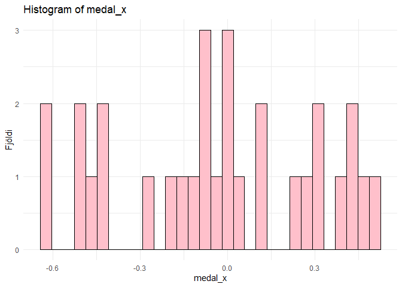

```r
ggplot(urtak30, aes(x = medal_x)) +
  geom_histogram(fill = "pink", color = "black", bins = 30) +
  labs(title = "Histogram of medal_x", x = "medal_x", y = "Fjöldi") +
  theme_minimal()
```

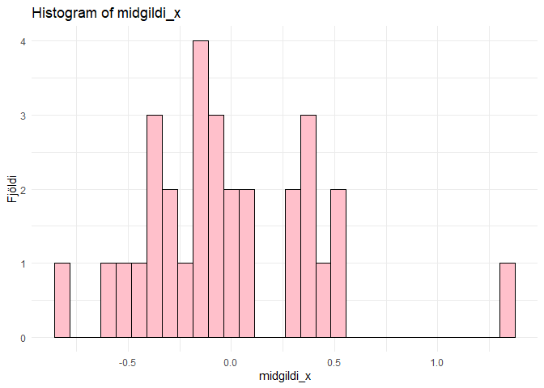

```r
ggplot(urtak30, aes(x = midgildi_x)) +
  geom_histogram(fill = "pink", color = "black", bins = 30) +
  labs(title = "Histogram of midgildi_x", x = "midgildi_x", y = "Fjöldi") +
  theme_minimal()
```

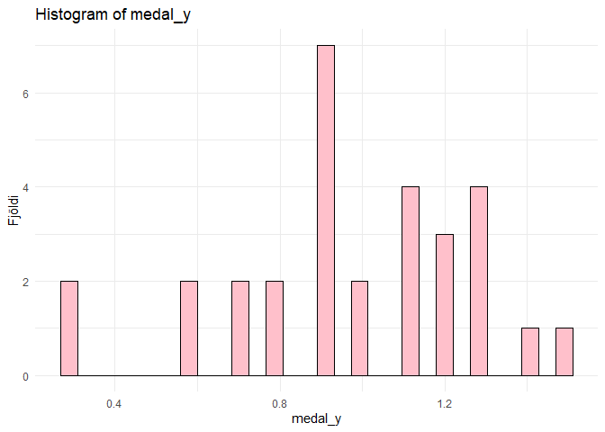

```r
ggplot(urtak30, aes(x = medal_y)) +
  geom_histogram(fill = "pink", color = "black", bins = 30) +
  labs(title = "Histogram of medal_y", x = "medal_y", y = "Fjöldi") +
  theme_minimal()
```

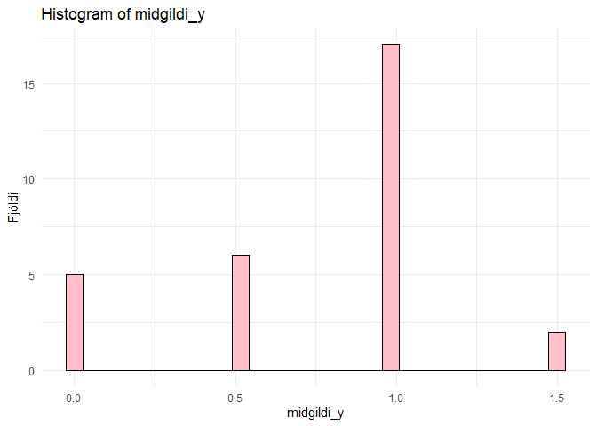

```r
ggplot(urtak30, aes(x = midgildi_y)) +
  geom_histogram(fill = "pink", color = "black", bins = 30) +
  labs(title = "Histogram of midgildi_y", x = "midgildi_y", y = "Fjöldi") +
  theme_minimal()
```

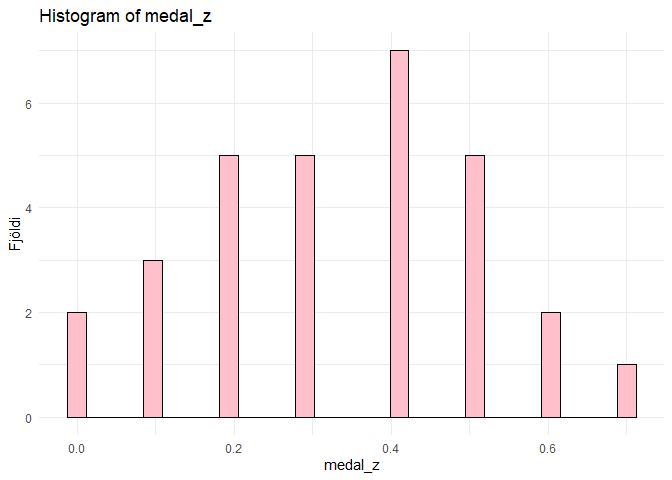

```r
ggplot(urtak30, aes(x = medal_z)) +
  geom_histogram(fill = "pink", color = "black", bins = 30) +
  labs(title = "Histogram of medal_z", x = "medal_z", y = "Fjöldi") +
  theme_minimal()
```

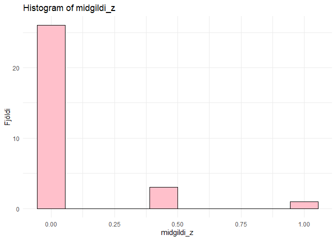

```r
ggplot(urtak30, aes(x = midgildi_z)) +
  geom_histogram(fill = "pink", color = "black", bins = 10) +
  labs(title = "Histogram of midgildi_z", x = "midgildi_z", y = "Fjöldi") +
  theme_minimal()
```

```r
mean30 <- colMeans(urtak30) #meðaltal
var30 <- apply(urtak30, 2, var) #dreifni

tafla30 <- data.frame(Mean = mean30, Variance = var30)

knitr::kable(tafla30)
```

|  | Mean | Variance |
| --- | --- | --- |
| medal_x | -0.0328869 | 0.1123000 |
| midgildi_x | -0.0167188 | 0.1810152 |
| medal_y | 0.9733333 | 0.0875402 |
| midgildi_y | 0.7666667 | 0.1850575 |
| medal_z | 0.3333333 | 0.0319540 |
| midgildi_z | 0.0833333 | 0.0531609 |

Samhverf: midgildi_x, medal_z

Nú er meðaltal X nær væntigildinu, enn ekki nærri því jafn nálægt og Y og Z, sem eru aftur heldur nálægt væntigildum sínum

Sjáum að munurinn á drefini meðaltals og miðgildis sömu slembistærðar er heldur stór, en dreifnin á miðgildinu er u.þ.b helmingin meiri en á meðaltali sömu stærðar

#### Liður 5: Stækkum úrtakið enn meir (n=100)

- Endurtakið liði 2 og 3, nema nú fyrir úrtak af stærð 100.

```r
urtak100 <- sample_n(dat10, 100)
knitr::kable(urtak100)
```

| medal_x | midgildi_x | medal_y | midgildi_y | medal_z | midgildi_z |
| --- | --- | --- | --- | --- | --- |
| -0.1296868 | 0.1602018 | 1.0 | 0.5 | 0.2 | 0.0 |
| -0.2497203 | 0.3760828 | 0.9 | 0.0 | 0.4 | 0.5 |
| -0.1430162 | -0.2025126 | 0.6 | 1.0 | 0.0 | 0.0 |
| 0.1938615 | 0.0335765 | 0.9 | 1.0 | 0.3 | 0.0 |
| 0.5461779 | -0.5952826 | 1.1 | 0.5 | 0.2 | 0.0 |
| -0.1014018 | -0.1887051 | 0.9 | 1.0 | 0.2 | 0.0 |
| -0.4322729 | -0.9703180 | 1.0 | 1.0 | 0.3 | 0.0 |
| -0.0418819 | -0.1461841 | 0.8 | 0.5 | 0.3 | 0.5 |
| 0.3062832 | -0.0515433 | 1.5 | 0.0 | 0.5 | 0.0 |
| -0.2490973 | -0.0856087 | 1.0 | 1.0 | 0.7 | 0.0 |
| 0.1445124 | 0.7682263 | 0.4 | 1.0 | 0.5 | 0.0 |
| -0.0290107 | -0.4389314 | 1.3 | 1.0 | 0.2 | 0.0 |
| -0.1633191 | 0.2563655 | 0.6 | 1.0 | 0.2 | 0.0 |
| 0.3459984 | -0.1584723 | 0.8 | 1.0 | 0.3 | 0.0 |
| -0.3255948 | -0.2680989 | 0.8 | 1.0 | 0.4 | 0.5 |
| 0.0682951 | -0.3625259 | 0.9 | 0.0 | 0.5 | 0.0 |
| -0.3616335 | -0.1987076 | 1.2 | 1.0 | 0.6 | 0.0 |
| -0.0174765 | -0.3128467 | 0.9 | 0.5 | 0.2 | 0.0 |
| -0.1860839 | 0.3568374 | 0.5 | 1.0 | 0.0 | 0.0 |
| 0.5397649 | -0.1395696 | 1.0 | 0.5 | 0.3 | 0.0 |
| -0.0421363 | -0.7077027 | 0.9 | 0.5 | 0.3 | 0.0 |
| 0.0870233 | -0.6975621 | 0.8 | 1.0 | 0.0 | 0.0 |
| -0.3945962 | -0.5213611 | 1.0 | 1.0 | 0.0 | 0.0 |
| 0.2908953 | -0.3931833 | 0.8 | 1.5 | 0.1 | 0.0 |
| 0.1403287 | -0.2675521 | 1.6 | 1.0 | 0.2 | 0.0 |
| -0.0490015 | -0.2003588 | 1.0 | 0.5 | 0.2 | 0.0 |
| 0.0217592 | 0.0154272 | 1.0 | 1.0 | 0.2 | 0.0 |
| 0.0412581 | -0.1172774 | 0.9 | 1.0 | 0.2 | 0.0 |
| -0.1260331 | 0.1531388 | 0.5 | 1.5 | 0.6 | 0.0 |
| -0.3630739 | 0.1811171 | 1.2 | 1.0 | 0.2 | 0.0 |

[output cut: 70 more lines]

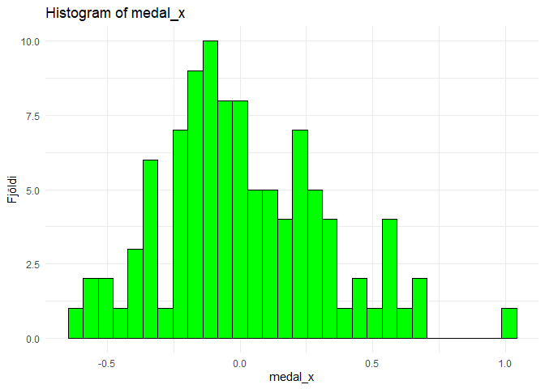

```r
ggplot(urtak100, aes(x = medal_x)) +
  geom_histogram(fill = "green", color = "black", bins = 30) +
  labs(title = "Histogram of medal_x", x = "medal_x", y = "Fjöldi") +
  theme_minimal()
```

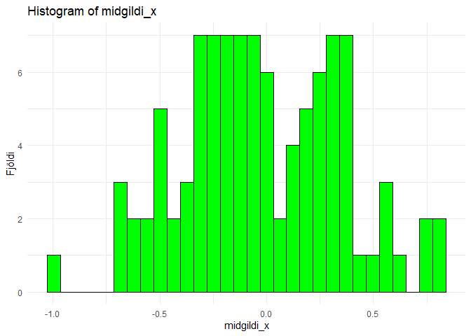

```r
ggplot(urtak100, aes(x = midgildi_x)) +
  geom_histogram(fill = "green", color = "black", bins = 30) +
  labs(title = "Histogram of midgildi_x", x = "midgildi_x", y = "Fjöldi") +
  theme_minimal()
```

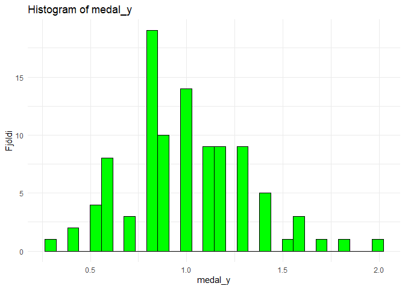

```r
ggplot(urtak100, aes(x = medal_y)) +
  geom_histogram(fill = "green", color = "black", bins = 30) +
  labs(title = "Histogram of medal_y", x = "medal_y", y = "Fjöldi") +
  theme_minimal()
```

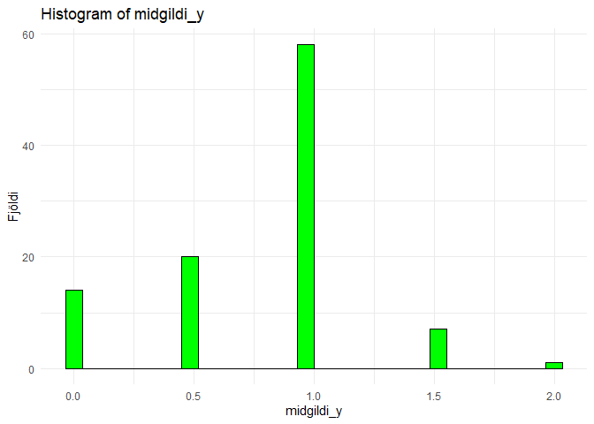

```r
ggplot(urtak100, aes(x = midgildi_y)) +
  geom_histogram(fill = "green", color = "black", bins = 30) +
  labs(title = "Histogram of midgildi_y", x = "midgildi_y", y = "Fjöldi") +
  theme_minimal()
```

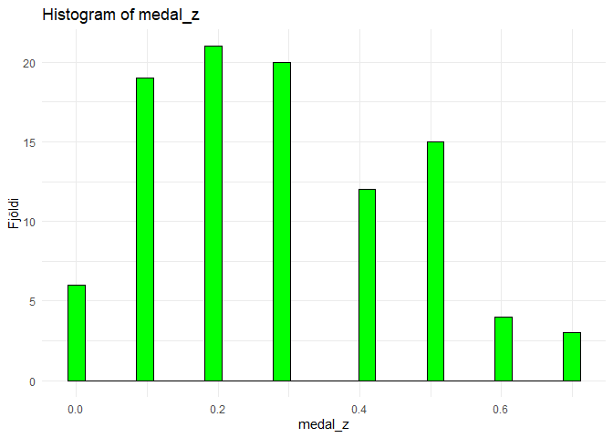

```r
ggplot(urtak100, aes(x = medal_z)) +
  geom_histogram(fill = "green", color = "black", bins = 30) +
  labs(title = "Histogram of medal_z", x = "medal_z", y = "Fjöldi") +
  theme_minimal()
```

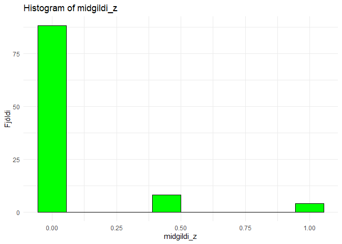

```r
ggplot(urtak100, aes(x = midgildi_z)) +
  geom_histogram(fill = "green", color = "black", bins = 10) +
  labs(title = "Histogram of midgildi_z", x = "midgildi_z", y = "Fjöldi") +
  theme_minimal()
```

```r
mean100 <- colMeans(urtak100) #meðaltal
var100 <- apply(urtak100, 2, var) #dreifni

tafla100 <- data.frame(Mean = mean100, Variance = var100)

knitr::kable(tafla100)
```

|  | Mean | Variance |
| --- | --- | --- |
| medal_x | 0.0145838 | 0.0955087 |
| midgildi_x | -0.0248289 | 0.1362853 |
| medal_y | 0.9940000 | 0.1023879 |
| midgildi_y | 0.8050000 | 0.1812879 |
| medal_z | 0.2890000 | 0.0308879 |
| midgildi_z | 0.0800000 | 0.0541414 |

Samfelld: medal_x

Þessi breytistærð er án efa sú sem skilaði meðaltali næst væntigildinu fyrir allar stærðirnar. Y og Z eru nánæst þær sömu, og X hefur aldrei verið nær.

Sjáum að munurinn á drefini meðaltals og miðgildis sömu slembistærðar er heldur stór, en dreifnin á miðgildinu er u.þ.b helmingin meiri en á meðaltali sömu stærðar

#### Liður 6: Berum saman úrtaksstærðir

- Beriið núna saman úrtaksdreifingu **meðaltals** fyrir slembistærðirnar X, Y og Z fyrir þessar þrjár ólíku úrtaksstærðir. Hversu stórt þurfti úrtakið að vera (n=10, n=30 eða n=100) til að úrtaksdreifing meðaltalsins líktist normaldreifingu?

Fyrir n=10 leit úrtaksdreifing meðaltals ekkert eins og normaldreifing.

Þegar úrtakið stækkaði í n= 30, byrjaði úrtaksdreifingin að líta aðeins út eins og normaldreifing, en þó ekki alveg.

Það var ekki fyrr en í n=100, þegar við gátum verið vissar að grafið sem við sáum var normaldreift

#### Framlag hópameðlima

Báðir meðlimir unnu saman að öllum liðum, en með áherslu á ólýka liði.

Vilborg: 1, 2, 6

Ásgerður: 3, 4, 5